# R Notebook

```r
library(dplyr)
library(ggplot2)
library(data.table)
# head(mysurvey)
df <- copy[, c("Q2.2", "Q164")]
head(df)
```

| Q2.2 | Q164 |
| --- | --- |
| iOS (iPhone) | NA |
| Android | NA |
| Android | NA |
| Android | NA |
| iOS (iPhone) | NA |
| iOS (iPhone) | NA |

```r
str(df)
```

```
tibble [214 × 2] (S3: tbl_df/tbl/data.frame)
 $ Q2.2: Ord.factor w/ 4 levels "Android"<"iOS (iPhone)"<..: 2 1 1 1 2 2 1 2 1 2 ...
  ..- attr(*, "label")= Named chr " Selected Choice"
  .. ..- attr(*, "names")= chr "Q2.2"
 $ Q164: Ord.factor w/ 7 levels "0"<"1-2"<"3-5"<..: 7 7 7 7 7 7 7 7 7 1 ...
  ..- attr(*, "label")= Named chr "How many times have you experienced negative experiences related to notifications?"
  .. ..- attr(*, "names")= chr "Q164"
```

```r
### to remove NAs first convert to factors!
df <- df %>% mutate_if(is.factor, as.character)
# df$Q164 <- as.character(df$Q164)
df <- df[!is.na(df$Q164) , ]
df <- df[df$Q164 != "NA" , ]
# df$Q164[ is.na(df$Q164) ] <- "Not reported"
### convert back to factor for analysis
df$Q164 <- factor(df$Q164, levels = c("0", "1-2", "3-5", "6-10", "11-20", "More than 20", ordered = TRUE))
df$Q2.2 <- factor(df$Q2.2, levels= c("Android", "iOS (iPhone)"))
summary(df)
```

```
           Q2.2               Q164
 Android     :166   0           :70
 iOS (iPhone): 38   1-2         :53
                    3-5         :56
                    6-10        :16
                    11-20       : 4
                    More than 20: 5
                    TRUE        : 0
```

```r
summary(df$Q2.2)
```

```
     Android iOS (iPhone)
         166           38
```

```r
# unique(df$Q164)
```

```r
table(df$Q164, df$Q2.2)
```

```
               Android iOS (iPhone)
  0                 56           14
  1-2               45            8
  3-5               47            9
  6-10              13            3
  11-20              2            2
  More than 20       3            2
  TRUE               0            0
```

```r
100*prop.table(table(df$Q164, df$Q2.2))
```

```
                  Android iOS (iPhone)
  0            27.4509804    6.8627451
  1-2          22.0588235    3.9215686
  3-5          23.0392157    4.4117647
  6-10          6.3725490    1.4705882
  11-20         0.9803922    0.9803922
  More than 20  1.4705882    0.9803922
  TRUE          0.0000000    0.0000000
```

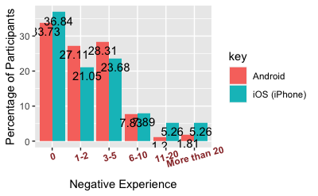

```r
count <- df %>% count(Q164, Q2.2)
for(i in 1:nrow(count)){
  if(i%%2==0){
      count[i,c("per")] <- 100*(count[i,c("n")] / 38)
  }
  else{
     count[i,c("per")] <- 100*(count[i,c("n")] / 166)
  }
}
count$per <- round(count$per, 2)
setnames(count, old = c("Q2.2"), new = c('key'))
image <- ggplot(count, aes(Q164, y = per , fill= key)) +geom_bar(stat='identity', position='dodge') +  labs(x = "Negative Experience",  y = "Percentage of Participants") + theme(axis.text.x = element_text(face = "bold", color = "#993333", size = 9, angle = 15)) + geom_text(aes(label = per), position = position_dodge(0.9),vjust = 1.5)
plot(image)
```

### Perform Test for statistical significance between the groups

#### Kruskal Wallis

One independent variable with two or more levels. The test is more commonly used when there are three or more levels. For two levels instead of the Kruskal-Wallis test consider using the Mann Whitney U Test.

```r
result = kruskal.test(Q164 ~ Q2.2,   data = df)
print(result)
```

```
    Kruskal-Wallis rank sum test

data:  Q164 by Q2.2
Kruskal-Wallis chi-squared = 0.10691, df = 1, p-value = 0.7437
```

```r
#
# install.packages("dplyr" ,dependencies = TRUE)
# install.packages(c("Rcpp","tidyverse"))
# library(tidyverse)
install.packages("ggpubr")
# library(ggpubr)
# library(rstatix)
# df %>% group_by(Q164) %>% get_summary_stats(Q2.2, type = "common")
```

#### Mann Whitney U Test

- It is a popular nonparametric (distribution-free) test to compare outcomes between two independent groups.
- When comparing two independent samples, when the outcome is not normally distributed and the samples are small, a nonparametric test is appropriate.
- It is used to see the distribution difference between two independent variables on the basis of an ordinal(categorical variable having intrinsic an order or rank) dependent variable.
- The major difference between the Mann-Whitney U and the Kruskal-Wallis H is simply that the latter can accommodate more than two groups. Both tests require independent (between-subjects) designs and use summed rank scores to determine the results.

```r
print(res)
```

```
    Wilcoxon rank sum test with continuity correction

data:  Q164 by Q2.2
W = 3051, p-value = 0.7449
alternative hypothesis: true location shift is not equal to 0
```

```r
print(w)
```

```
[1] 3154
```

[Source](https://miningthedetails.com/blog/r/non-parametric-tests/)

```r
count[]<- round(count[, 2:6],2)
```

```
Error: Can't recycle input of size 5 to size 6.
Run `rlang::last_error()` to see where the error occurred.
```